# Introduction SQL in RStudio, part 3 - Anwers

Antoinette Littel

June 2019

In part 3 you are prepared for your assesment with open assignments. This workbook provides the answers, so you can review your results.

## Connecting to the database

The first chunk in this Notebook will run automatically when you make the SQL statements. It loads the libraries you need and connects to the database ‘machine.db’ that should be in your folder.

## Database design

Below is the design of the database. You should have this picture in the images folder of your workdirectory. You can open the picture next to your Notebook, so that you can see the design while creating your queries.

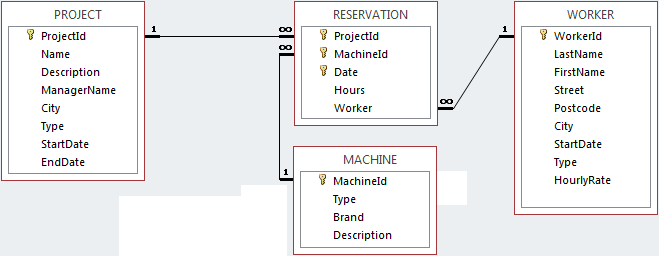

## Assignments

Make a SQL query for the following questions.

1. List all the projects that started in 2018 and ended in 2018.

[output not shown]

2. Give the total number of workers that live in Eindhoven and have an hourly rate of more than 20 euros/hr.

| NumberOfWorkers |
| --- |
| 2 |

3. List the projects where manager name is Jane plus the projects where city is not Eindhoven and manager name is not Jane.

| ProjectID | Name | Description | ManagerName | City | Type | StartDate | EndDate |
| --- | --- | --- | --- | --- | --- | --- | --- |
| 2 | Adaption | Redesign Matrix 1.0 | Jane | Eindhoven | G | 2019-05-01 |  |
| 3 | Generic1 | Make cups | Jim | Tilburg | C | 2019-05-01 |  |
| 4 | Peanuts | Make peanuts | Jim | Tilburg | C | 2020-01-01 |  |
| 5 | Bananas | Make bananas | Jane | Eindhoven | G | 2019-12-31 |  |

4. Give average hourly rate of all full-time Workers per city, but only when there are more than 1 worker coming from that city.

| City | avg(hourlyrate) | Workers |
| --- | --- | --- |
| Eindhoven | 30 | 2 |
| Nuenen | 60 | 2 |

5. Give first name and last name of the workers who have worked on projects with project ids between 2 and 6 (both values are inclusive) and who have first name ending with letters ‘rd’. Using a subquery is mandatory!

| FirstName | LastName |
| --- | --- |
| Jord | Littel |
| Glard | Smit |

6. Give the project name, project type, machine type, brand for the machines of type ‘Loader’, ‘Roller’ and ‘Dumper’. Sort the result in alphabetical order of project type and then in reverse alphabetical order of machine type.

| ProjectName | ProjectType | MachineType | MachineBrand |
| --- | --- | --- | --- |
| Generic1 | C | Dumper | KnittingFury |
| Generic1 | C | Dumper | KnittingFury |
| Bananas | G | Roller | MoldingFast |
| Revolution | G | Loader | MoldingFast |
| Revolution | G | Dumper | KnittingFury |
| Revolution | G | Dumper | KnittingFury |

7. List per machineID and description the number of projects that reserved that machine.

| MachineID | Description | NumberOfProjects |
| --- | --- | --- |
| 122 | Plastic molds silver thickness 12 | 1 |
| 123 | Plastic molds silver thickness 10 | 1 |
| 1000 | Knitting 12 colours | 4 |

8. List for each reserved machine, the workers firstname and lastname that reserved that machine.

| FirstName | LastName | MachineID |
| --- | --- | --- |
| John | Smit | 122 |
| John | Smit | 1000 |
| James | Laro | 1000 |
| Antoinette | Littel | 1000 |
| Jord | Littel | 1000 |
| Glard | Smit | 123 |